# Basic Data Wrangling & Exploration, ft. Tidyverse

Kursus R: Pengenalan dan Praktikal

Mohd Azmi Bin Suliman

azmi.suliman@moh.gov.my

Pusat Penyelidikan Penyakit Tak Berjangkit, Institut Kesihatan Umum

Wednesday, 06 March 2024

# Packages

## Packages in R

- The strength of R is it’s open-source philosophy
- When installing R, you get a basic set of packages
- Package in R is a collection of functions, data, and compiled code
- R allow for custom function, and even custom package
- The custom package can be shared with others, e.g., via CRAN
- These custom packages enriched the R ecosystem

## Packages in R

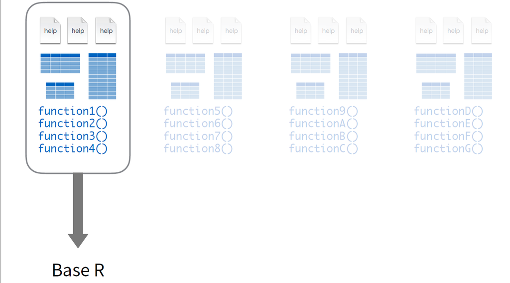

## Packages in R

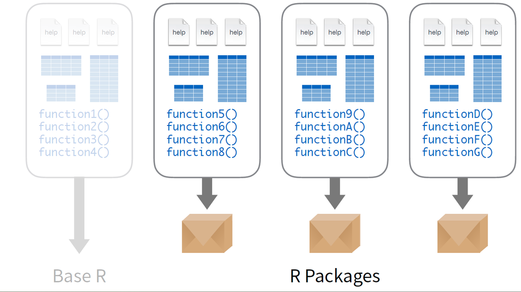

## Packages in R

- Among common packages in R

| Package | Description |
| --- | --- |
| tidyverse | collection of packages designed for data science |
| haven | import/export SPSS, Stata and SAS files |
| readxl | import/export excel files |
| lubridate | work with date and time |
| ggplot2 | data visualisation |
| dplyr | data manipulation |
| stringr | string manipulation |
| forcats | factor manipulation |
| broom | tidy statistical output |
| modelr | modelling functions |

## Packages in R

- Install once
  - using `install.packages("package_name")`
  - can also click on `install` button at `Packages` pane
- Load every time you use R
  - using `library(package_name)`
  - can also tick at respective library at `Packages` pane

## Packages in R

- Lets try install `tibble` package using code

```r
install.packages("tibble")
```

- Then load the package using code

```r
library(tibble)
```

# Can you try install `tidyverse` package?

# Data Wrangling

## What is data wrangling?

- real world data commonly messy!
- 80% of time taken spend on data cleaning
- improving data quality > improving the accuracy & efficiency
- data wrangling involving **tidying** and **transforming** data, from raw form to analysis-ready data.
- common data wrangling action
  - label data
  - recategorise categorical variable - usually collapsing groups
  - binning continuous variable

# Lets try some data wrangling

## Setup your project

- We will use
  - current project `R_Practical`
  - current Quarto document `Sesi 1 Pengenalan`
- Add new level 1 header
  - Single # symbol
  - Followed by the title `Data Wrangling`

## Setup your project

[figure not shown]

# Import Dataset

## Import Dataset

- We will use the `asthma_ds.sav` dataset (SPSS file)
- Copy the dataset to the `R_Practical` project folder (working directory)
- Add new level 2 header
  - Double ## symbol
  - Followed by the title `Import Dataset`
- Insert new R code chunk

## Import Dataset

[figure not shown]

## Import Dataset

- We will use the `read_sav` `haven` package to import the dataset
- The dataset is stored in R object `asthma_ds0`

```r
library(tidyverse)
library(haven)

asthma_ds0 <- read_sav("asthma_ds.sav")
```

## Import Dataset

- We can view the dataset by writing the object name

```r
asthma_ds0
```

```
# A tibble: 150 × 16
      id idR   Gender       Age WorkStatus   Height Weight_Pre PA_HW Weight_Post
   <dbl> <chr> <dbl+lbl>  <dbl> <dbl+lbl>     <dbl>      <dbl> <dbl>       <dbl>
 1     1 nXSw  2 [Female]    34 2 [Unemploy…    179       84.2     5        76.7
 2     2 yg2t  1 [Male]      31 2 [Unemploy…    169       81.8     1        75.7
 3     3 QBW4  1 [Male]      25 1 [Employed]    164       88.5     1        84.1
 4     4 2x2S  2 [Female]    33 2 [Unemploy…    136       53.2     4        46.9
 5     5 mOnn  1 [Male]      28 2 [Unemploy…    172       71.3     2        63.3
 6     6 D3sl  1 [Male]      33 2 [Unemploy…    178       87.3     0        82.6
 7     7 le6j  2 [Female]    31 2 [Unemploy…    140       48.8     5        41.9
 8     8 r3gC  2 [Female]    34 1 [Employed]    140       49.1     2        43.6
 9     9 3Tyt  1 [Male]      31 1 [Employed]    171       60.1     1        54.7
10    10 cmKF  1 [Male]      28 1 [Employed]    163       93.1     1        86.2
# ℹ 140 more rows
# ℹ 7 more variables: Tx2 <dbl+lbl>, PEFR_Pre <dbl>, PEFR_Post <dbl>,
#   SxWheeze_Pre <dbl+lbl>, SxWheeze_Post <dbl+lbl>, PS_Pre <dbl>,
#   PS_Post <dbl>
```

## Import Dataset

- We can also use `View` function (capital V)

```r
View(asthma_ds0)
```

## Import Dataset

- In this dataset, we can notice that the `Gender` variable is coded as `1` and `2`, with label `Male` and `Female` respectively.
- Similar to other factor (categorical) variables in this dataset.
- This is common in SPSS dataset, where the label is stored separately from the data.
- We can use `as_factor` function to convert the variable to factor, and apply the label to the factor.

```r
asthma_ds <- as_factor(asthma_ds0)
```

## Import Dataset

```r
asthma_ds
```

```
# A tibble: 150 × 16
      id idR   Gender   Age WorkStatus Height Weight_Pre PA_HW Weight_Post Tx2
   <dbl> <chr> <fct>  <dbl> <fct>       <dbl>      <dbl> <dbl>       <dbl> <fct>
 1     1 nXSw  Female    34 Unemployed    179       84.2     5        76.7 Drug…
 2     2 yg2t  Male      31 Unemployed    169       81.8     1        75.7 Plac…
 3     3 QBW4  Male      25 Employed      164       88.5     1        84.1 Drug…
 4     4 2x2S  Female    33 Unemployed    136       53.2     4        46.9 Drug…
 5     5 mOnn  Male      28 Unemployed    172       71.3     2        63.3 Plac…
 6     6 D3sl  Male      33 Unemployed    178       87.3     0        82.6 Drug…
 7     7 le6j  Female    31 Unemployed    140       48.8     5        41.9 Plac…
 8     8 r3gC  Female    34 Employed      140       49.1     2        43.6 Plac…
 9     9 3Tyt  Male      31 Employed      171       60.1     1        54.7 Drug…
10    10 cmKF  Male      28 Employed      163       93.1     1        86.2 Plac…
# ℹ 140 more rows
# ℹ 6 more variables: PEFR_Pre <dbl>, PEFR_Post <dbl>, SxWheeze_Pre <fct>,
#   SxWheeze_Post <fct>, PS_Pre <dbl>, PS_Post <dbl>
```

# Simple Data Wrangling

## Select Variable/Column

- We can select variable/column using `select` function
- We can use `:` to select range of variable

```r
asthma_ds1 <- select(asthma_ds, idR:Weight_Post)

asthma_ds1
```

```
# A tibble: 150 × 8
   idR   Gender   Age WorkStatus Height Weight_Pre PA_HW Weight_Post
   <chr> <fct>  <dbl> <fct>       <dbl>      <dbl> <dbl>       <dbl>
 1 nXSw  Female    34 Unemployed    179       84.2     5        76.7
 2 yg2t  Male      31 Unemployed    169       81.8     1        75.7
 3 QBW4  Male      25 Employed      164       88.5     1        84.1
 4 2x2S  Female    33 Unemployed    136       53.2     4        46.9
 5 mOnn  Male      28 Unemployed    172       71.3     2        63.3
 6 D3sl  Male      33 Unemployed    178       87.3     0        82.6
 7 le6j  Female    31 Unemployed    140       48.8     5        41.9
 8 r3gC  Female    34 Employed      140       49.1     2        43.6
 9 3Tyt  Male      31 Employed      171       60.1     1        54.7
10 cmKF  Male      28 Employed      163       93.1     1        86.2
# ℹ 140 more rows
```

## Arithmetic Transformation

```r
asthma_ds2 <- asthma_ds1
asthma_ds2$Ht_m <- asthma_ds2$Height/100
asthma_ds2$BMI_Pre <- asthma_ds2$Weight_Pre/(asthma_ds2$Ht_m^2)

asthma_ds2
```

```
# A tibble: 150 × 10
   idR   Gender   Age WorkStatus Height Weight_Pre PA_HW Weight_Post  Ht_m
   <chr> <fct>  <dbl> <fct>       <dbl>      <dbl> <dbl>       <dbl> <dbl>
 1 nXSw  Female    34 Unemployed    179       84.2     5        76.7  1.79
 2 yg2t  Male      31 Unemployed    169       81.8     1        75.7  1.69
 3 QBW4  Male      25 Employed      164       88.5     1        84.1  1.64
 4 2x2S  Female    33 Unemployed    136       53.2     4        46.9  1.36
 5 mOnn  Male      28 Unemployed    172       71.3     2        63.3  1.72
 6 D3sl  Male      33 Unemployed    178       87.3     0        82.6  1.78
 7 le6j  Female    31 Unemployed    140       48.8     5        41.9  1.4
 8 r3gC  Female    34 Employed      140       49.1     2        43.6  1.4
 9 3Tyt  Male      31 Employed      171       60.1     1        54.7  1.71
10 cmKF  Male      28 Employed      163       93.1     1        86.2  1.63
# ℹ 140 more rows
# ℹ 1 more variable: BMI_Pre <dbl>
```

## Binning Continuous Variable

- We can bin continuous variable using `cut` function
  - For example, we can bin `BMI_Pre` variable into 4 categories

| BMI Category | BMI Range |
| --- | --- |
| Underweight | <= 18.49 |
| Normal | 18.50 - 22.99 |
| Overweight | 23.00 - 24.99 |
| Obese | >= 25.00 |

## Binning Continuous Variable

- For example, we can bin `BMI_Pre` variable into 4 categories

```r
asthma_ds3 <- asthma_ds2
asthma_ds3$BMI_PreCat <- cut(asthma_ds3$BMI_Pre,
                             breaks = c(0, 18.49, 22.99, 24.99, 100),
                             labels = c("Underweight", "Normal", "Overweight", "Obese"))

asthma_ds3
```

```
# A tibble: 150 × 11
   idR   Gender   Age WorkStatus Height Weight_Pre PA_HW Weight_Post  Ht_m
   <chr> <fct>  <dbl> <fct>       <dbl>      <dbl> <dbl>       <dbl> <dbl>
 1 nXSw  Female    34 Unemployed    179       84.2     5        76.7  1.79
 2 yg2t  Male      31 Unemployed    169       81.8     1        75.7  1.69
 3 QBW4  Male      25 Employed      164       88.5     1        84.1  1.64
 4 2x2S  Female    33 Unemployed    136       53.2     4        46.9  1.36
 5 mOnn  Male      28 Unemployed    172       71.3     2        63.3  1.72
 6 D3sl  Male      33 Unemployed    178       87.3     0        82.6  1.78
 7 le6j  Female    31 Unemployed    140       48.8     5        41.9  1.4
 8 r3gC  Female    34 Employed      140       49.1     2        43.6  1.4
 9 3Tyt  Male      31 Employed      171       60.1     1        54.7  1.71
10 cmKF  Male      28 Employed      163       93.1     1        86.2  1.63
# ℹ 140 more rows
# ℹ 2 more variables: BMI_Pre <dbl>, BMI_PreCat <fct>
```

# Tidyverse

## What is Tidyverse?

- Tidyverse is a collection of packages designed for data science
- The strength of Tidyverse is the **tidy** data philosophy
- Pipe operator `%>%` is the main feature of Tidyverse
- The packages are:

| Package | Description |
| --- | --- |
| ggplot2 | data visualisation |
| dplyr | data manipulation |
| tidyr | data tidying |
| readr | data import |
| purrr | functional programming |
| tibble | data structure |
| stringr | string manipulation |
| forcats | factor manipulation |
| broom | tidy statistical output |
| modelr | modelling functions |

## How does tidyverse make code more readable?

- Tidyverse is designed to work together
- `mutate` function is used to create new variable
- While pipe operator `%>%` is used to chain multiple function
- These two were commonly used in Tidyverse

## `mutate` function

- `mutate` function is used to
  - create new variable
  - modify existing variable

```r
asthma_ds4 <- asthma_ds1
asthma_ds4 <- mutate(asthma_ds4, Ht_m = Height/100)
asthma_ds4
```

```
# A tibble: 150 × 9
   idR   Gender   Age WorkStatus Height Weight_Pre PA_HW Weight_Post  Ht_m
   <chr> <fct>  <dbl> <fct>       <dbl>      <dbl> <dbl>       <dbl> <dbl>
 1 nXSw  Female    34 Unemployed    179       84.2     5        76.7  1.79
 2 yg2t  Male      31 Unemployed    169       81.8     1        75.7  1.69
 3 QBW4  Male      25 Employed      164       88.5     1        84.1  1.64
 4 2x2S  Female    33 Unemployed    136       53.2     4        46.9  1.36
 5 mOnn  Male      28 Unemployed    172       71.3     2        63.3  1.72
 6 D3sl  Male      33 Unemployed    178       87.3     0        82.6  1.78
 7 le6j  Female    31 Unemployed    140       48.8     5        41.9  1.4
 8 r3gC  Female    34 Employed      140       49.1     2        43.6  1.4
 9 3Tyt  Male      31 Employed      171       60.1     1        54.7  1.71
10 cmKF  Male      28 Employed      163       93.1     1        86.2  1.63
# ℹ 140 more rows
```

## `mutate` function + Pipe Operator

- We can use pipe operator `%>%` to chain multiple function

## Example of Data Wrangling **without** Pipe Operator

```r
asthma_ds0 <- read_sav("asthma_ds.sav")
asthma_ds1 <- as_factor(asthma_ds0)
asthma_ds2 <- select(asthma_ds1, idR:Weight_Post)
asthma_ds3 <- asthma_ds2
asthma_ds3$Ht_m <- asthma_ds3$Height/100
asthma_ds3$BMI_Pre <- asthma_ds3$Weight_Pre/(asthma_ds3$Ht_m^2)
asthma_ds3$BMI_PreCat <- cut(asthma_ds3$BMI_Pre,
                             breaks = c(0, 18.49, 22.99, 24.99, 100),
                             labels = c("Underweight", "Normal", "Overweight", "Obese"))
asthma_ds3
```

```
# A tibble: 150 × 11
   idR   Gender   Age WorkStatus Height Weight_Pre PA_HW Weight_Post  Ht_m
   <chr> <fct>  <dbl> <fct>       <dbl>      <dbl> <dbl>       <dbl> <dbl>
 1 nXSw  Female    34 Unemployed    179       84.2     5        76.7  1.79
 2 yg2t  Male      31 Unemployed    169       81.8     1        75.7  1.69
 3 QBW4  Male      25 Employed      164       88.5     1        84.1  1.64
 4 2x2S  Female    33 Unemployed    136       53.2     4        46.9  1.36
 5 mOnn  Male      28 Unemployed    172       71.3     2        63.3  1.72
 6 D3sl  Male      33 Unemployed    178       87.3     0        82.6  1.78
 7 le6j  Female    31 Unemployed    140       48.8     5        41.9  1.4
 8 r3gC  Female    34 Employed      140       49.1     2        43.6  1.4
 9 3Tyt  Male      31 Employed      171       60.1     1        54.7  1.71
10 cmKF  Male      28 Employed      163       93.1     1        86.2  1.63
# ℹ 140 more rows
# ℹ 2 more variables: BMI_Pre <dbl>, BMI_PreCat <fct>
```

## Example of Data Wrangling **with** Pipe Operator

```r
asthma_ds5 <- read_sav("asthma_ds.sav") %>%
  as_factor() %>%
  select(idR:Weight_Post) %>%
  mutate(Ht_m = Height/100,
         BMI_Pre = Weight_Pre/(Ht_m^2),
         BMI_PreCat = cut(BMI_Pre, breaks = c(0, 18.49, 22.99, 24.99, 100),
                          labels = c("Underweight", "Normal", "Overweight", "Obese")))

asthma_ds5
```

```
# A tibble: 150 × 11
   idR   Gender   Age WorkStatus Height Weight_Pre PA_HW Weight_Post  Ht_m
   <chr> <fct>  <dbl> <fct>       <dbl>      <dbl> <dbl>       <dbl> <dbl>
 1 nXSw  Female    34 Unemployed    179       84.2     5        76.7  1.79
 2 yg2t  Male      31 Unemployed    169       81.8     1        75.7  1.69
 3 QBW4  Male      25 Employed      164       88.5     1        84.1  1.64
 4 2x2S  Female    33 Unemployed    136       53.2     4        46.9  1.36
 5 mOnn  Male      28 Unemployed    172       71.3     2        63.3  1.72
 6 D3sl  Male      33 Unemployed    178       87.3     0        82.6  1.78
 7 le6j  Female    31 Unemployed    140       48.8     5        41.9  1.4
 8 r3gC  Female    34 Employed      140       49.1     2        43.6  1.4
 9 3Tyt  Male      31 Employed      171       60.1     1        54.7  1.71
10 cmKF  Male      28 Employed      163       93.1     1        86.2  1.63
# ℹ 140 more rows
# ℹ 2 more variables: BMI_Pre <dbl>, BMI_PreCat <fct>
```

# Data Exploration with Tidyverse

## Data Exploration

- Data exploration is the first step in data analysis
- But data exploration also commonly use at various stage of data analysis

## Summary Statistics with `summarise` function

- Tidyverse provide various function to get summary statistics
  - `summarise` function

```r
asthma_ds5 %>%
  summarise(Mean_Height = mean(Height),
            SD_Height = sd(Height),
            Min_Height = min(Height),
            Max_Height = max(Height))
```

```
# A tibble: 1 × 4
  Mean_Height SD_Height Min_Height Max_Height
        <dbl>     <dbl>      <dbl>      <dbl>
1        164.      15.3        129        195
```

## Summary Statistics with `count` function

- `count` function is used to count the frequency of each level of a factor variable

```r
asthma_ds5 %>%
  count(Gender)
```

```
# A tibble: 2 × 2
  Gender     n
  <fct>  <int>
1 Male      86
2 Female    64
```

## Summary Statistics with `group_by` function

- `group_by` function is used to group the data by a factor variable

```r
asthma_ds5 %>%
  group_by(Gender) %>%
  summarise(Mean_Height = mean(Height),
            SD_Height = sd(Height),
            Min_Height = min(Height),
            Max_Height = max(Height))
```

```
# A tibble: 2 × 5
  Gender Mean_Height SD_Height Min_Height Max_Height
  <fct>        <dbl>     <dbl>      <dbl>      <dbl>
1 Male          174.      8.98        151        195
2 Female        150.     11.0         129        179
```

## Cross Tabulation with `table` function

- `table` function is used for crosstabulation

```r
with(asthma_ds5, table(WorkStatus, Gender))
```

```
            Gender
WorkStatus   Male Female
  Employed     53     17
  Unemployed   33     47
```

## Plot: Histogram

- We can quickly plot histogram using base R function `hist`

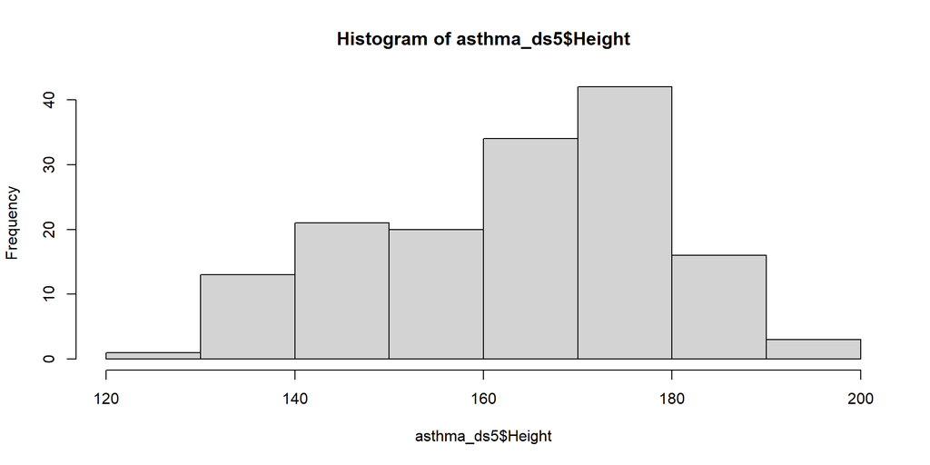

```r
hist(asthma_ds5$Height)
```

## Plot: Bar Chart

- We can quickly plot bar chart using base R function `barplot`

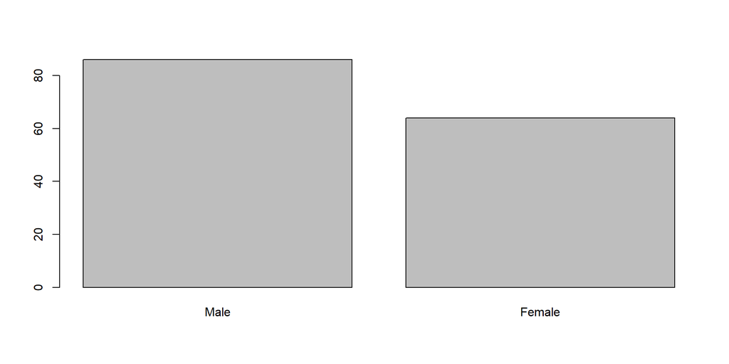

```r
barplot(table(asthma_ds5$Gender))
```

# Finish! See you next week~

Basic Data Wrangling & Exploration, ft. Tidyverse